# CSC 180 Final Project: Classifying Diabetes Risk Among Patient Questionnaires

### Spring 2021

Derek Sakasegawa (219500607)  
Eric Wong (219515297)  
Jack Tran(219589865)  
Dr. Chen  
5/3/21

## Data Preprocessing

In this section, we will be loading the data which is filled with answers to a questionnaire by numerous patients. The answers provided by each patient will be used for training in our AI models to predict whether or not each patient is at risk of diabetes or not. Listed below are some helper functions.

```python
import csv
import pandas as pd
import matplotlib.pyplot as plt
import numpy as np
import shutil
import os
import tensorflow as tf
import time
from sklearn import preprocessing
from sklearn.exceptions import NotFittedError
from collections.abc import Sequence
from sklearn.model_selection import train_test_split
from sklearn.metrics import confusion_matrix
from tensorflow.keras.datasets import mnist
from tensorflow.keras.layers import Dense, Dropout, Flatten
from tensorflow.keras.layers import Conv2D, MaxPooling2D
from tensorflow.keras.models import Sequential
from tensorflow.keras.layers import Activation
from tensorflow.keras.callbacks import EarlyStopping
from tensorflow.keras.optimizers import Adam
from sklearn.metrics import classification_report
from sklearn.metrics import accuracy_score
from sklearn.ensemble import RandomForestClassifier
from sklearn.neighbors import KNeighborsClassifier
from sklearn.svm import SVC
from sklearn import metrics

def plot_confusion_matrix(cm, names, title='Confusion matrix', cmap=plt.cm.Blues):
    plt.imshow(cm, interpolation='nearest', cmap=cmap)
    plt.title(title)
    plt.colorbar()
    tick_marks = np.arange(len(names))
    plt.xticks(tick_marks, names, rotation=45)
    plt.yticks(tick_marks, names)
    plt.tight_layout()
    plt.ylabel('True label')
    plt.xlabel('Predicted label')

def hms_string(sec_elapsed):
    h = int(sec_elapsed / (60 * 60))
    m = int((sec_elapsed % (60 * 60)) / 60)
    s = sec_elapsed % 60
    return "{}:{:>02}:{:>05.2f}".format(h, m, s)

def encode_numeric_range(df, name, normalized_low=-1, normalized_high=1,
                         data_low=None, data_high=None):
    if data_low is None:
        data_low = min(df[name])
        data_high = max(df[name])

    df[name] = ((df[name] - data_low) / (data_high - data_low)) * (normalized_high - normalized_low) + normalized_low

def encode_text_index(df, name):
    le = preprocessing.LabelEncoder()
    df[name] = le.fit_transform(df[name])
    return le.classes_

def to_xy(df, target):
    result = []
    for x in df.columns:
        if x != target:
            result.append(x)
    # find out the type of the target column.
    target_type = df[target].dtypes
    target_type = target_type[0] if isinstance(target_type, Sequence) else target_type
    # Encode to int for classification, float otherwise. TensorFlow likes 32 bits.
    if target_type in (np.int64, np.int32):
        # Classification
        dummies = pd.get_dummies(df[target])
        return df[result].values.astype(np.float32), dummies.values.astype(np.float32)
    else:
        # Regression
        return df[result].values.astype(np.float32), df[target].values.astype(np.float32)


df = pd.read_csv("diabetes_data_upload.csv", na_values=['NA','?'])

df.columns = ['age','gender','polyuria', 'polydipsia', 'sudden_weight_loss', 'weakness', 'polyphagia', 'genital_thrush', 'visual_blurring', 'itching',
              'irritability', 'delayed_healing', 'partial_paresis', 'muscle_stiffness', 'alopecia', 'obesity', 'class']
```

Here, we are showing off the data that is going to be used for training and testing in this project.

```python
df
```

|  | age | gender | polyuria | polydipsia | sudden_weight_loss | weakness | polyphagia | genital_thrush | visual_blurring | itching | irritability | delayed_healing | partial_paresis | muscle_stiffness | alopecia | obesity | class |
| --- | --- | --- | --- | --- | --- | --- | --- | --- | --- | --- | --- | --- | --- | --- | --- | --- | --- |
| 0 | 40 | Male | No | Yes | No | Yes | No | No | No | Yes | No | Yes | No | Yes | Yes | Yes | Positive |
| 1 | 58 | Male | No | No | No | Yes | No | No | Yes | No | No | No | Yes | No | Yes | No | Positive |
| 2 | 41 | Male | Yes | No | No | Yes | Yes | No | No | Yes | No | Yes | No | Yes | Yes | No | Positive |
| 3 | 45 | Male | No | No | Yes | Yes | Yes | Yes | No | Yes | No | Yes | No | No | No | No | Positive |
| 4 | 60 | Male | Yes | Yes | Yes | Yes | Yes | No | Yes | Yes | Yes | Yes | Yes | Yes | Yes | Yes | Positive |
| ... | ... | ... | ... | ... | ... | ... | ... | ... | ... | ... | ... | ... | ... | ... | ... | ... | ... |
| 515 | 39 | Female | Yes | Yes | Yes | No | Yes | No | No | Yes | No | Yes | Yes | No | No | No | Positive |
| 516 | 48 | Female | Yes | Yes | Yes | Yes | Yes | No | No | Yes | Yes | Yes | Yes | No | No | No | Positive |
| 517 | 58 | Female | Yes | Yes | Yes | Yes | Yes | No | Yes | No | No | No | Yes | Yes | No | Yes | Positive |
| 518 | 32 | Female | No | No | No | Yes | No | No | Yes | Yes | No | Yes | No | No | Yes | No | Negative |
| 519 | 42 | Male | No | No | No | No | No | No | No | No | No | No | No | No | No | No | Negative |

520 rows × 17 columns

We check here for any missing values in the dataset, so we can drop them if there are any. However, it appears there are none.

```python
df.isnull().sum()
```

```
age                   0
gender                0
polyuria              0
polydipsia            0
sudden_weight_loss    0
weakness              0
polyphagia            0
genital_thrush        0
visual_blurring       0
itching               0
irritability          0
delayed_healing       0
partial_paresis       0
muscle_stiffness      0
alopecia              0
obesity               0
class                 0
dtype: int64
```

## Encoding Categorical Features

Now we encode each categorical feature to a numeric value as part of our preprocessing of the data.

```python
encode_text_index(df, 'gender')
encode_text_index(df, 'polyuria')
encode_text_index(df, 'polydipsia')
encode_text_index(df, 'sudden_weight_loss')
encode_text_index(df, 'weakness')
encode_text_index(df, 'polyphagia')
encode_text_index(df, 'genital_thrush')
encode_text_index(df, 'visual_blurring')
encode_text_index(df, 'itching')
encode_text_index(df, 'irritability')
encode_text_index(df, 'delayed_healing')
encode_text_index(df, 'partial_paresis')
encode_text_index(df, 'muscle_stiffness')
encode_text_index(df, 'alopecia')
encode_text_index(df, 'obesity')
encode_text_index(df, 'class')
```

```
array(['Negative', 'Positive'], dtype=object)
```

Here, we display the dataframe again to show that all attributes that had categorical values have been label encoded properly.

```python
df
```

|  | age | gender | polyuria | polydipsia | sudden_weight_loss | weakness | polyphagia | genital_thrush | visual_blurring | itching | irritability | delayed_healing | partial_paresis | muscle_stiffness | alopecia | obesity | class |
| --- | --- | --- | --- | --- | --- | --- | --- | --- | --- | --- | --- | --- | --- | --- | --- | --- | --- |
| 0 | 40 | 1 | 0 | 1 | 0 | 1 | 0 | 0 | 0 | 1 | 0 | 1 | 0 | 1 | 1 | 1 | 1 |
| 1 | 58 | 1 | 0 | 0 | 0 | 1 | 0 | 0 | 1 | 0 | 0 | 0 | 1 | 0 | 1 | 0 | 1 |
| 2 | 41 | 1 | 1 | 0 | 0 | 1 | 1 | 0 | 0 | 1 | 0 | 1 | 0 | 1 | 1 | 0 | 1 |
| 3 | 45 | 1 | 0 | 0 | 1 | 1 | 1 | 1 | 0 | 1 | 0 | 1 | 0 | 0 | 0 | 0 | 1 |
| 4 | 60 | 1 | 1 | 1 | 1 | 1 | 1 | 0 | 1 | 1 | 1 | 1 | 1 | 1 | 1 | 1 | 1 |
| ... | ... | ... | ... | ... | ... | ... | ... | ... | ... | ... | ... | ... | ... | ... | ... | ... | ... |
| 515 | 39 | 0 | 1 | 1 | 1 | 0 | 1 | 0 | 0 | 1 | 0 | 1 | 1 | 0 | 0 | 0 | 1 |
| 516 | 48 | 0 | 1 | 1 | 1 | 1 | 1 | 0 | 0 | 1 | 1 | 1 | 1 | 0 | 0 | 0 | 1 |
| 517 | 58 | 0 | 1 | 1 | 1 | 1 | 1 | 0 | 1 | 0 | 0 | 0 | 1 | 1 | 0 | 1 | 1 |
| 518 | 32 | 0 | 0 | 0 | 0 | 1 | 0 | 0 | 1 | 1 | 0 | 1 | 0 | 0 | 1 | 0 | 0 |
| 519 | 42 | 1 | 0 | 0 | 0 | 0 | 0 | 0 | 0 | 0 | 0 | 0 | 0 | 0 | 0 | 0 | 0 |

520 rows × 17 columns

Next, we will show roughly about how many patients in the dataset were classified as nondiabetic and diabetic. Note: Nondiabetic was encoded to a value of 0 and diabetic was encoded to a value of 1.

It can be seen that roughly 200 patients are classified as nondiabetic and 320 are classified as diabetic.

```python
df[df['class']== 0]
```

|  | age | gender | polyuria | polydipsia | sudden_weight_loss | weakness | polyphagia | genital_thrush | visual_blurring | itching | irritability | delayed_healing | partial_paresis | muscle_stiffness | alopecia | obesity | class |
| --- | --- | --- | --- | --- | --- | --- | --- | --- | --- | --- | --- | --- | --- | --- | --- | --- | --- |
| 200 | 40 | 1 | 0 | 1 | 1 | 1 | 0 | 0 | 1 | 1 | 0 | 0 | 1 | 1 | 0 | 0 | 0 |
| 201 | 28 | 1 | 0 | 0 | 1 | 0 | 0 | 0 | 0 | 0 | 0 | 0 | 0 | 0 | 0 | 0 | 0 |
| 202 | 37 | 1 | 0 | 0 | 0 | 0 | 0 | 0 | 0 | 0 | 0 | 0 | 0 | 0 | 0 | 0 | 0 |
| 203 | 34 | 1 | 0 | 0 | 0 | 0 | 0 | 0 | 0 | 0 | 0 | 0 | 0 | 0 | 0 | 0 | 0 |
| 204 | 30 | 1 | 0 | 0 | 0 | 0 | 0 | 0 | 0 | 0 | 0 | 0 | 0 | 0 | 0 | 0 | 0 |
| ... | ... | ... | ... | ... | ... | ... | ... | ... | ... | ... | ... | ... | ... | ... | ... | ... | ... |
| 510 | 67 | 1 | 0 | 0 | 0 | 1 | 0 | 0 | 0 | 1 | 0 | 1 | 0 | 0 | 1 | 0 | 0 |
| 511 | 66 | 1 | 0 | 0 | 0 | 1 | 1 | 0 | 1 | 1 | 0 | 1 | 1 | 1 | 1 | 0 | 0 |
| 512 | 43 | 1 | 0 | 0 | 0 | 0 | 0 | 0 | 0 | 0 | 0 | 0 | 0 | 0 | 1 | 0 | 0 |
| 518 | 32 | 0 | 0 | 0 | 0 | 1 | 0 | 0 | 1 | 1 | 0 | 1 | 0 | 0 | 1 | 0 | 0 |
| 519 | 42 | 1 | 0 | 0 | 0 | 0 | 0 | 0 | 0 | 0 | 0 | 0 | 0 | 0 | 0 | 0 | 0 |

200 rows × 17 columns

```python
df[df['class']== 1]
```

|  | age | gender | polyuria | polydipsia | sudden_weight_loss | weakness | polyphagia | genital_thrush | visual_blurring | itching | irritability | delayed_healing | partial_paresis | muscle_stiffness | alopecia | obesity | class |
| --- | --- | --- | --- | --- | --- | --- | --- | --- | --- | --- | --- | --- | --- | --- | --- | --- | --- |
| 0 | 40 | 1 | 0 | 1 | 0 | 1 | 0 | 0 | 0 | 1 | 0 | 1 | 0 | 1 | 1 | 1 | 1 |
| 1 | 58 | 1 | 0 | 0 | 0 | 1 | 0 | 0 | 1 | 0 | 0 | 0 | 1 | 0 | 1 | 0 | 1 |
| 2 | 41 | 1 | 1 | 0 | 0 | 1 | 1 | 0 | 0 | 1 | 0 | 1 | 0 | 1 | 1 | 0 | 1 |
| 3 | 45 | 1 | 0 | 0 | 1 | 1 | 1 | 1 | 0 | 1 | 0 | 1 | 0 | 0 | 0 | 0 | 1 |
| 4 | 60 | 1 | 1 | 1 | 1 | 1 | 1 | 0 | 1 | 1 | 1 | 1 | 1 | 1 | 1 | 1 | 1 |
| ... | ... | ... | ... | ... | ... | ... | ... | ... | ... | ... | ... | ... | ... | ... | ... | ... | ... |
| 513 | 62 | 0 | 1 | 1 | 1 | 1 | 0 | 0 | 1 | 0 | 0 | 0 | 1 | 0 | 0 | 1 | 1 |
| 514 | 54 | 0 | 1 | 1 | 1 | 1 | 1 | 0 | 0 | 0 | 0 | 0 | 1 | 0 | 0 | 0 | 1 |
| 515 | 39 | 0 | 1 | 1 | 1 | 0 | 1 | 0 | 0 | 1 | 0 | 1 | 1 | 0 | 0 | 0 | 1 |
| 516 | 48 | 0 | 1 | 1 | 1 | 1 | 1 | 0 | 0 | 1 | 1 | 1 | 1 | 0 | 0 | 0 | 1 |
| 517 | 58 | 0 | 1 | 1 | 1 | 1 | 1 | 0 | 1 | 0 | 0 | 0 | 1 | 1 | 0 | 1 | 1 |

320 rows × 17 columns

## Splitting Data into Test and Training

Now we specify our inputs and outputs for the models and algorithms. Then they are split for training and testing.

```python
x = df.drop("class", axis=1)
y = df["class"]
x_train, x_test, y_train, y_test = train_test_split(x, y, test_size = 0.2, random_state = 42)
x_train.shape, y_train.shape
```

```
((416, 16), (416,))
```

## Random Forest Algorithm

```python
rf_model = RandomForestClassifier(n_estimators = 100)
rf_model.fit(x_train,y_train)
```

```
RandomForestClassifier(bootstrap=True, ccp_alpha=0.0, class_weight=None,
                       criterion='gini', max_depth=None, max_features='auto',
                       max_leaf_nodes=None, max_samples=None,
                       min_impurity_decrease=0.0, min_impurity_split=None,
                       min_samples_leaf=1, min_samples_split=2,
                       min_weight_fraction_leaf=0.0, n_estimators=100,
                       n_jobs=None, oob_score=False, random_state=None,
                       verbose=0, warm_start=False)
```

```python
predictions_rf = rf_model.predict(x_test)
```

```python
score = accuracy_score(y_test, predictions_rf)
print("Final Accuracy for Random Forest: {}".format(score))
```

```
Final Accuracy for Random Forest: 0.9903846153846154
```

Here, we are testing if model's performance in predicting 20 patients' condition after implementing the Random Forest algorithm.

```python
df_rf = pd.DataFrame({"Predicted": predictions_rf , "Actual": y_test})
df_rf[0:20]
```

|  | Predicted | Actual |
| --- | --- | --- |
| 275 | 0 | 0 |
| 93 | 1 | 1 |
| 6 | 1 | 1 |
| 167 | 1 | 1 |
| 90 | 1 | 1 |
| 513 | 1 | 1 |
| 362 | 1 | 1 |
| 228 | 0 | 0 |
| 192 | 1 | 1 |
| 482 | 0 | 0 |
| 218 | 0 | 0 |
| 180 | 1 | 1 |
| 307 | 0 | 0 |
| 508 | 0 | 0 |
| 10 | 1 | 1 |
| 381 | 1 | 1 |
| 371 | 0 | 0 |
| 30 | 1 | 1 |
| 494 | 0 | 0 |
| 137 | 1 | 1 |

```python
cm2 = metrics.confusion_matrix(y_test, predictions_rf)
print(cm2)
```

```
[[33  0]
 [ 1 70]]
```

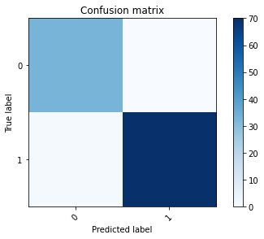

```python
classes = encode_text_index(df,"class")
plt.figure()
plot_confusion_matrix(cm2, classes)
plt.show()
```

```python
print(metrics.classification_report(y_test, predictions_rf))
```

```
              precision    recall  f1-score   support

           0       0.97      1.00      0.99        33
           1       1.00      0.99      0.99        71

    accuracy                           0.99       104
   macro avg       0.99      0.99      0.99       104
weighted avg       0.99      0.99      0.99       104
```

## KNN Algorithm

```python
model = KNeighborsClassifier(n_neighbors=3)
```

```python
model.fit(x_train, y_train)
```

```
KNeighborsClassifier(algorithm='auto', leaf_size=30, metric='minkowski',
                     metric_params=None, n_jobs=None, n_neighbors=3, p=2,
                     weights='uniform')
```

```python
predictions_knn = model.predict(x_test)
```

```python
score1 = accuracy_score(y_test, predictions_knn)
```

```python
print("Final Accuracy for KNN: {}".format(score1))
```

```
Final Accuracy for KNN: 0.875
```

Here we are showing how well our model performed after implementing the KNN algorithm.

```python
df_knn = pd.DataFrame({"Predicted Values": predictions_knn , "Actual Values": y_test})
df_knn[40:60]
```

|  | Predicted Values | Actual Values |
| --- | --- | --- |
| 299 | 1 | 1 |
| 347 | 1 | 0 |
| 55 | 0 | 1 |
| 515 | 1 | 1 |
| 519 | 0 | 0 |
| 158 | 1 | 1 |
| 222 | 0 | 0 |
| 255 | 1 | 1 |
| 153 | 1 | 1 |
| 176 | 1 | 1 |
| 210 | 0 | 0 |
| 289 | 0 | 0 |
| 76 | 1 | 1 |
| 447 | 1 | 1 |
| 349 | 0 | 0 |
| 148 | 0 | 1 |
| 446 | 1 | 1 |
| 73 | 1 | 1 |
| 2 | 1 | 1 |
| 77 | 1 | 1 |

```python
cm = metrics.confusion_matrix(y_test, predictions_knn)
print(cm)
```

```
[[30  3]
 [10 61]]
```

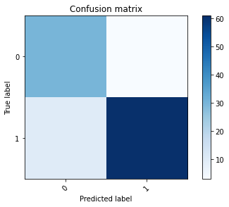

```python
plt.figure()
plot_confusion_matrix(cm, classes)
plt.show()
```

```python
print(metrics.classification_report(y_test, predictions_knn))
```

```
              precision    recall  f1-score   support

           0       0.75      0.91      0.82        33
           1       0.95      0.86      0.90        71

    accuracy                           0.88       104
   macro avg       0.85      0.88      0.86       104
weighted avg       0.89      0.88      0.88       104
```

## SVM Algorithm

```python
model = SVC(kernel = "linear")
```

```python
model.fit(x_train, y_train)
```

```
SVC(C=1.0, break_ties=False, cache_size=200, class_weight=None, coef0=0.0,
    decision_function_shape='ovr', degree=3, gamma='scale', kernel='linear',
    max_iter=-1, probability=False, random_state=None, shrinking=True,
    tol=0.001, verbose=False)
```

```python
predictions_svm = model.predict(x_test)
```

```python
score1 = accuracy_score(y_test, predictions_svm)
```

```python
print("Final Accuracy for SVM: {}".format(score1))
```

```
Final Accuracy for SVM: 0.8942307692307693
```

Here we show how well our model performed after implementing the SVM algorithm.

```python
df_svm = pd.DataFrame({"Predicted Values": predictions_svm , "Actual Values": y_test})
df_svm[90:110]
```

|  | Predicted Values | Actual Values |
| --- | --- | --- |
| 314 | 0 | 0 |
| 448 | 1 | 1 |
| 365 | 1 | 1 |
| 177 | 1 | 1 |
| 286 | 0 | 0 |
| 346 | 1 | 1 |
| 131 | 1 | 1 |
| 433 | 1 | 1 |
| 456 | 1 | 1 |
| 69 | 1 | 1 |
| 357 | 1 | 0 |
| 423 | 1 | 1 |
| 334 | 0 | 0 |
| 227 | 0 | 0 |

```python
cm = metrics.confusion_matrix(y_test, predictions_svm)
print(cm)
```

```
[[28  5]
 [ 6 65]]
```

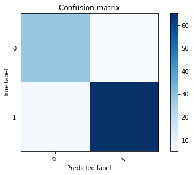

```python
plt.figure()
plot_confusion_matrix(cm, classes)
plt.show()
```

```python
print(metrics.classification_report(y_test, predictions_svm))
```

```
              precision    recall  f1-score   support

           0       0.82      0.85      0.84        33
           1       0.93      0.92      0.92        71

    accuracy                           0.89       104
   macro avg       0.88      0.88      0.88       104
weighted avg       0.90      0.89      0.89       104
```

## Fully Connected Neural Networks

Now we split and train the data again for the building of our fully connected neural network models.

```python
x, y = to_xy(df, 'class')
x_train, x_test, y_train, y_test = train_test_split(x, y, test_size = 0.2, random_state = 42)
x_train.shape, y_train.shape
```

```
((416, 16), (416, 2))
```

## Fully Connected Neural Network Model #1 (Using relu & adam)

```python
model = Sequential()

#Activation1
model.add(Dense(10, input_dim=x.shape[1], activation='relu')) # Hidden 1
model.add(Dense(10, activation='relu')) # Hidden 2
model.add(Dense(10))
model.add(Dense(10))
model.add(Dense(1)) #1 Output neuron
model.add(Dense(y.shape[1],activation='relu'))

model.compile(loss='binary_crossentropy', optimizer='adam')

monitor = EarlyStopping(monitor='val_loss', min_delta=1e-5, patience=5, verbose=2, mode='auto')

model.fit(x_train,y_train,validation_data=(x_test,y_test),callbacks=[monitor],verbose=2,epochs=1000)
```

```
13/13 - 1s - loss: 4.8505 - val_loss: 1.0240
13/13 - 0s - loss: 1.1889 - val_loss: 1.0835
13/13 - 0s - loss: 0.9517 - val_loss: 1.0715
13/13 - 0s - loss: 0.8998 - val_loss: 0.9231
13/13 - 0s - loss: 0.8477 - val_loss: 0.9978
13/13 - 0s - loss: 0.8208 - val_loss: 0.8618
13/13 - 0s - loss: 0.8031 - val_loss: 0.8369
13/13 - 0s - loss: 0.7901 - val_loss: 0.8283
13/13 - 0s - loss: 0.7763 - val_loss: 0.8023
13/13 - 0s - loss: 0.7643 - val_loss: 0.7866
13/13 - 0s - loss: 0.7536 - val_loss: 0.7736
13/13 - 0s - loss: 0.7457 - val_loss: 0.7664
13/13 - 0s - loss: 0.7368 - val_loss: 0.7501
13/13 - 0s - loss: 0.7306 - val_loss: 0.7422
13/13 - 0s - loss: 0.7229 - val_loss: 0.7310
13/13 - 0s - loss: 0.7171 - val_loss: 0.7230
13/13 - 0s - loss: 0.7119 - val_loss: 0.7158
13/13 - 0s - loss: 0.7072 - val_loss: 0.7078
13/13 - 0s - loss: 0.7030 - val_loss: 0.7023
13/13 - 0s - loss: 0.6997 - val_loss: 0.6954
13/13 - 0s - loss: 0.6962 - val_loss: 0.6905
13/13 - 0s - loss: 0.6933 - val_loss: 0.6862
13/13 - 0s - loss: 0.6913 - val_loss: 0.6812
13/13 - 0s - loss: 0.6887 - val_loss: 0.6774
13/13 - 0s - loss: 0.6865 - val_loss: 0.6740
13/13 - 0s - loss: 0.6843 - val_loss: 0.6703
13/13 - 0s - loss: 0.6826 - val_loss: 0.6677
13/13 - 0s - loss: 0.6811 - val_loss: 0.6644
13/13 - 0s - loss: 0.6796 - val_loss: 0.6622
13/13 - 0s - loss: 0.6785 - val_loss: 0.6600
13/13 - 0s - loss: 0.6775 - val_loss: 0.6577
13/13 - 0s - loss: 0.6765 - val_loss: 0.6563
13/13 - 0s - loss: 0.6752 - val_loss: 0.6543
13/13 - 0s - loss: 0.6744 - val_loss: 0.6526
13/13 - 0s - loss: 0.6734 - val_loss: 0.6515
13/13 - 0s - loss: 0.6725 - val_loss: 0.6503
13/13 - 0s - loss: 0.6717 - val_loss: 0.6492
13/13 - 0s - loss: 0.6713 - val_loss: 0.6483
13/13 - 0s - loss: 0.6708 - val_loss: 0.6463
13/13 - 0s - loss: 0.6696 - val_loss: 0.6456
```

[output cut: 44 more lines]

```
13/13 - 0s - loss: 0.5768 - val_loss: 0.5673
13/13 - 0s - loss: 0.5625 - val_loss: 0.5581
13/13 - 0s - loss: 0.5599 - val_loss: 0.5769
13/13 - 0s - loss: 0.5794 - val_loss: 0.5728
13/13 - 0s - loss: 0.5750 - val_loss: 0.6219
13/13 - 0s - loss: 0.5724 - val_loss: 0.5444
13/13 - 0s - loss: 0.5404 - val_loss: 0.5367
13/13 - 0s - loss: 0.5343 - val_loss: 0.5302
13/13 - 0s - loss: 0.5261 - val_loss: 0.5289
13/13 - 0s - loss: 2.3259 - val_loss: 2.9227
13/13 - 0s - loss: 3.5381 - val_loss: 2.9198
13/13 - 0s - loss: 3.5142 - val_loss: 2.8796
13/13 - 0s - loss: 3.4870 - val_loss: 2.8475
13/13 - 0s - loss: 3.4684 - val_loss: 2.8267
Epoch 00098: early stopping
```

```
<tensorflow.python.keras.callbacks.History at 0x7f652081b2d0>
```

```python
pred = model.predict(x_test)
pred = np.argmax(pred, axis=1)
y_true = np.argmax(y_test, axis=1)

score = metrics.accuracy_score(y_true, pred)

print("Accuracy score: {}".format(score))
```

```
Accuracy score: 0.6826923076923077
```

```python
print(metrics.classification_report(y_true, pred))
```

```
              precision    recall  f1-score   support

           0       0.00      0.00      0.00        33
           1       0.68      1.00      0.81        71

    accuracy                           0.68       104
   macro avg       0.34      0.50      0.41       104
weighted avg       0.47      0.68      0.55       104
```

## Fully Connected Neural Network Model #2 (Using sigmoid & adam)

```python
model = Sequential()

#Activation 2
model.add(Dense(10, input_dim=x.shape[1], activation='sigmoid')) # Hidden 1
model.add(Dense(10, activation='sigmoid')) # Hidden 2
model.add(Dense(10))
model.add(Dense(10))
model.add(Dense(1)) #1 Output neuron
model.add(Dense(y.shape[1],activation='sigmoid'))

model.compile(loss='binary_crossentropy', optimizer='adam')

monitor = EarlyStopping(monitor='val_loss', min_delta=1e-5, patience=5, verbose=2, mode='auto')

model.fit(x_train,y_train,validation_data=(x_test,y_test),callbacks=[monitor],verbose=2,epochs=1000)
```

```
13/13 - 1s - loss: 0.6908 - val_loss: 0.6831
13/13 - 0s - loss: 0.6871 - val_loss: 0.6746
13/13 - 0s - loss: 0.6852 - val_loss: 0.6704
13/13 - 0s - loss: 0.6839 - val_loss: 0.6680
13/13 - 0s - loss: 0.6829 - val_loss: 0.6655
13/13 - 0s - loss: 0.6818 - val_loss: 0.6634
13/13 - 0s - loss: 0.6807 - val_loss: 0.6624
13/13 - 0s - loss: 0.6799 - val_loss: 0.6590
13/13 - 0s - loss: 0.6792 - val_loss: 0.6594
13/13 - 0s - loss: 0.6775 - val_loss: 0.6549
13/13 - 0s - loss: 0.6765 - val_loss: 0.6520
13/13 - 0s - loss: 0.6754 - val_loss: 0.6499
13/13 - 0s - loss: 0.6741 - val_loss: 0.6469
13/13 - 0s - loss: 0.6727 - val_loss: 0.6452
13/13 - 0s - loss: 0.6712 - val_loss: 0.6440
13/13 - 0s - loss: 0.6688 - val_loss: 0.6388
13/13 - 0s - loss: 0.6656 - val_loss: 0.6350
13/13 - 0s - loss: 0.6616 - val_loss: 0.6279
13/13 - 0s - loss: 0.6555 - val_loss: 0.6217
13/13 - 0s - loss: 0.6454 - val_loss: 0.6063
13/13 - 0s - loss: 0.6305 - val_loss: 0.5935
13/13 - 0s - loss: 0.6073 - val_loss: 0.5638
13/13 - 0s - loss: 0.5701 - val_loss: 0.5228
13/13 - 0s - loss: 0.5187 - val_loss: 0.4695
13/13 - 0s - loss: 0.4519 - val_loss: 0.4063
13/13 - 0s - loss: 0.3844 - val_loss: 0.3849
13/13 - 0s - loss: 0.3232 - val_loss: 0.3094
13/13 - 0s - loss: 0.2911 - val_loss: 0.3170
13/13 - 0s - loss: 0.2650 - val_loss: 0.2983
13/13 - 0s - loss: 0.2484 - val_loss: 0.2833
13/13 - 0s - loss: 0.2431 - val_loss: 0.3055
13/13 - 0s - loss: 0.2189 - val_loss: 0.2753
13/13 - 0s - loss: 0.2182 - val_loss: 0.2828
13/13 - 0s - loss: 0.2086 - val_loss: 0.2664
13/13 - 0s - loss: 0.2087 - val_loss: 0.2651
13/13 - 0s - loss: 0.2009 - val_loss: 0.2616
13/13 - 0s - loss: 0.1978 - val_loss: 0.2651
13/13 - 0s - loss: 0.2010 - val_loss: 0.2575
13/13 - 0s - loss: 0.1994 - val_loss: 0.2750
13/13 - 0s - loss: 0.1945 - val_loss: 0.2523
```

[output cut: 190 more lines]

```
13/13 - 0s - loss: 0.0448 - val_loss: 0.0547
13/13 - 0s - loss: 0.0444 - val_loss: 0.0529
13/13 - 0s - loss: 0.0447 - val_loss: 0.0533
13/13 - 0s - loss: 0.0474 - val_loss: 0.0527
13/13 - 0s - loss: 0.0499 - val_loss: 0.0718
13/13 - 0s - loss: 0.0545 - val_loss: 0.0510
13/13 - 0s - loss: 0.0455 - val_loss: 0.0507
13/13 - 0s - loss: 0.0454 - val_loss: 0.0491
13/13 - 0s - loss: 0.0399 - val_loss: 0.0471
13/13 - 0s - loss: 0.0389 - val_loss: 0.0485
13/13 - 0s - loss: 0.0401 - val_loss: 0.0518
13/13 - 0s - loss: 0.0426 - val_loss: 0.0555
13/13 - 0s - loss: 0.0402 - val_loss: 0.0485
13/13 - 0s - loss: 0.0390 - val_loss: 0.0476
Epoch 00244: early stopping
```

```
<tensorflow.python.keras.callbacks.History at 0x7f651bf98e10>
```

```python
pred2 = model.predict(x_test)
pred2 = np.argmax(pred2, axis=1)
y_true = np.argmax(y_test, axis=1)

score = metrics.accuracy_score(y_true, pred2)

print("Accuracy score: {}".format(score))
```

```
Accuracy score: 0.9807692307692307
```

```python
print(metrics.classification_report(y_true, pred2))
```

```
              precision    recall  f1-score   support

           0       0.97      0.97      0.97        33
           1       0.99      0.99      0.99        71

    accuracy                           0.98       104
   macro avg       0.98      0.98      0.98       104
weighted avg       0.98      0.98      0.98       104
```

## Fully Connected Neural Network Model #3 (Using tanh & adam)

```python
model = Sequential()

#Activation3
model.add(Dense(10, input_dim=x.shape[1], activation='tanh')) # Hidden 1
model.add(Dense(30, activation='tanh')) # Hidden 2
model.add(Dense(10))
model.add(Dense(10))
model.add(Dense(1)) #1 Output neuron
model.add(Dense(y.shape[1],activation='tanh'))

model.compile(loss='binary_crossentropy', optimizer='adam')

monitor = EarlyStopping(monitor='val_loss', min_delta=1e-5, patience=5, verbose=2, mode='auto')

model.fit(x_train,y_train,validation_data=(x_test,y_test),callbacks=[monitor],verbose=2,epochs=1000)
```

```
13/13 - 1s - loss: 3.4486 - val_loss: 2.7625
13/13 - 0s - loss: 3.4361 - val_loss: 2.7601
13/13 - 0s - loss: 3.4397 - val_loss: 2.8127
13/13 - 0s - loss: 3.4464 - val_loss: 2.7647
13/13 - 0s - loss: 3.4341 - val_loss: 2.7675
13/13 - 0s - loss: 3.4315 - val_loss: 2.7635
13/13 - 0s - loss: 3.4146 - val_loss: 2.7252
13/13 - 0s - loss: 3.3974 - val_loss: 2.7053
13/13 - 0s - loss: 3.3635 - val_loss: 2.6789
13/13 - 0s - loss: 3.3481 - val_loss: 2.6659
13/13 - 0s - loss: 3.3405 - val_loss: 2.6619
13/13 - 0s - loss: 3.3187 - val_loss: 2.6445
13/13 - 0s - loss: 3.3346 - val_loss: 2.6862
13/13 - 0s - loss: 3.2757 - val_loss: 1.9465
13/13 - 0s - loss: 3.0123 - val_loss: 2.6771
13/13 - 0s - loss: 2.0274 - val_loss: 2.0209
13/13 - 0s - loss: 2.9057 - val_loss: 3.8512
13/13 - 0s - loss: 3.5091 - val_loss: 3.4626
13/13 - 0s - loss: 2.2798 - val_loss: 1.4751
13/13 - 0s - loss: 1.7755 - val_loss: 1.7697
13/13 - 0s - loss: 2.7733 - val_loss: 1.8680
13/13 - 0s - loss: 2.1388 - val_loss: 1.3707
13/13 - 0s - loss: 1.4423 - val_loss: 1.4141
13/13 - 0s - loss: 1.4315 - val_loss: 1.4721
13/13 - 0s - loss: 1.4867 - val_loss: 1.3162
13/13 - 0s - loss: 1.3735 - val_loss: 1.3110
13/13 - 0s - loss: 1.3628 - val_loss: 1.3066
13/13 - 0s - loss: 1.3554 - val_loss: 1.3041
13/13 - 0s - loss: 1.3493 - val_loss: 1.3032
13/13 - 0s - loss: 1.3684 - val_loss: 1.0610
13/13 - 0s - loss: 1.4092 - val_loss: 1.2564
13/13 - 0s - loss: 1.3302 - val_loss: 1.1554
13/13 - 0s - loss: 1.7526 - val_loss: 3.3155
13/13 - 0s - loss: 4.2111 - val_loss: 5.0228
13/13 - 0s - loss: 4.9018 - val_loss: 4.8053
Epoch 00035: early stopping
```

```
<tensorflow.python.keras.callbacks.History at 0x7f6511e70090>
```

```python
pred3 = model.predict(x_test)
pred3 = np.argmax(pred3, axis=1)
y_true = np.argmax(y_test, axis=1)

score = metrics.accuracy_score(y_true, pred3)

print("Accuracy score: {}".format(score))
```

```
Accuracy score: 0.5096153846153846
```

```python
print(metrics.classification_report(y_true, pred3))
```

```
              precision    recall  f1-score   support

           0       0.39      1.00      0.56        33
           1       1.00      0.28      0.44        71

    accuracy                           0.51       104
   macro avg       0.70      0.64      0.50       104
weighted avg       0.81      0.51      0.48       104
```

## Fully Connected Neural Network Model #4 (Using relu & sgd)

```python
model = Sequential()

#Activation 4
model.add(Dense(30, input_dim=x.shape[1], activation='relu')) # Hidden 1
model.add(Dense(15, activation='relu')) # Hidden 2
model.add(Dense(10,activation='relu'))
model.add(Dense(10,activation='relu'))
model.add(Dense(10,activation='relu'))
model.add(Dense(10,activation='relu'))
model.add(Dense(1)) #1 Output neuron
model.add(Dense(y.shape[1],activation='relu'))

model.compile(loss='binary_crossentropy', optimizer='sgd')

monitor = EarlyStopping(monitor='val_loss', min_delta=1e-5, patience=5, verbose=2, mode='auto')

model.fit(x_train,y_train,validation_data=(x_test,y_test),callbacks=[monitor],verbose=2,epochs=1000)
```

```
13/13 - 1s - loss: 7.7125 - val_loss: 7.7125
13/13 - 0s - loss: 7.7125 - val_loss: 7.7125
13/13 - 0s - loss: 7.7125 - val_loss: 7.7125
13/13 - 0s - loss: 7.7125 - val_loss: 7.7125
13/13 - 0s - loss: 7.7125 - val_loss: 7.7125
13/13 - 0s - loss: 7.7125 - val_loss: 7.7125
Epoch 00006: early stopping
```

```
<tensorflow.python.keras.callbacks.History at 0x7f652488af50>
```

```python
pred4 = model.predict(x_test)
pred4 = np.argmax(pred4, axis=1)
y_true = np.argmax(y_test, axis=1)

score = metrics.accuracy_score(y_true, pred4)

print("Accuracy score: {}".format(score))
```

```
Accuracy score: 0.3173076923076923
```

```python
print(metrics.classification_report(y_true, pred4))
```

```
              precision    recall  f1-score   support

           0       0.32      1.00      0.48        33
           1       0.00      0.00      0.00        71

    accuracy                           0.32       104
   macro avg       0.16      0.50      0.24       104
weighted avg       0.10      0.32      0.15       104
```

## Fully Connected Neural Network Model #5 (Using sigmoid & sgd)

```python
model = Sequential()

#Activation 5
model.add(Dense(30, input_dim=x.shape[1], activation='sigmoid')) # Hidden 1
model.add(Dense(15, activation='sigmoid')) # Hidden 2
model.add(Dense(20))
model.add(Dense(30))
model.add(Dense(1)) #1 Output neuron
model.add(Dense(y.shape[1],activation='sigmoid'))

model.compile(loss='binary_crossentropy', optimizer='sgd')

monitor = EarlyStopping(monitor='val_loss', min_delta=1e-5, patience=5, verbose=2, mode='auto')

model.fit(x_train,y_train,validation_data=(x_test,y_test),callbacks=[monitor],verbose=2,epochs=1000)
```

```
13/13 - 1s - loss: 0.7215 - val_loss: 0.6888
13/13 - 0s - loss: 0.7031 - val_loss: 0.6813
13/13 - 0s - loss: 0.6949 - val_loss: 0.6785
13/13 - 0s - loss: 0.6910 - val_loss: 0.6774
13/13 - 0s - loss: 0.6889 - val_loss: 0.6768
13/13 - 0s - loss: 0.6878 - val_loss: 0.6763
13/13 - 0s - loss: 0.6869 - val_loss: 0.6758
13/13 - 0s - loss: 0.6863 - val_loss: 0.6753
13/13 - 0s - loss: 0.6858 - val_loss: 0.6747
13/13 - 0s - loss: 0.6855 - val_loss: 0.6742
13/13 - 0s - loss: 0.6850 - val_loss: 0.6733
13/13 - 0s - loss: 0.6846 - val_loss: 0.6727
13/13 - 0s - loss: 0.6842 - val_loss: 0.6720
13/13 - 0s - loss: 0.6839 - val_loss: 0.6713
13/13 - 0s - loss: 0.6835 - val_loss: 0.6706
13/13 - 0s - loss: 0.6831 - val_loss: 0.6699
13/13 - 0s - loss: 0.6828 - val_loss: 0.6693
13/13 - 0s - loss: 0.6825 - val_loss: 0.6686
13/13 - 0s - loss: 0.6822 - val_loss: 0.6680
13/13 - 0s - loss: 0.6820 - val_loss: 0.6674
13/13 - 0s - loss: 0.6817 - val_loss: 0.6668
13/13 - 0s - loss: 0.6813 - val_loss: 0.6662
13/13 - 0s - loss: 0.6811 - val_loss: 0.6656
13/13 - 0s - loss: 0.6808 - val_loss: 0.6650
13/13 - 0s - loss: 0.6806 - val_loss: 0.6645
13/13 - 0s - loss: 0.6804 - val_loss: 0.6639
13/13 - 0s - loss: 0.6801 - val_loss: 0.6634
13/13 - 0s - loss: 0.6799 - val_loss: 0.6630
13/13 - 0s - loss: 0.6798 - val_loss: 0.6624
13/13 - 0s - loss: 0.6795 - val_loss: 0.6620
13/13 - 0s - loss: 0.6793 - val_loss: 0.6616
13/13 - 0s - loss: 0.6791 - val_loss: 0.6611
13/13 - 0s - loss: 0.6789 - val_loss: 0.6606
13/13 - 0s - loss: 0.6787 - val_loss: 0.6601
13/13 - 0s - loss: 0.6786 - val_loss: 0.6596
13/13 - 0s - loss: 0.6784 - val_loss: 0.6592
13/13 - 0s - loss: 0.6782 - val_loss: 0.6588
13/13 - 0s - loss: 0.6781 - val_loss: 0.6582
13/13 - 0s - loss: 0.6779 - val_loss: 0.6579
13/13 - 0s - loss: 0.6778 - val_loss: 0.6574
```

[output cut: 136 more lines]

```
13/13 - 0s - loss: 0.6733 - val_loss: 0.6406
13/13 - 0s - loss: 0.6733 - val_loss: 0.6406
13/13 - 0s - loss: 0.6733 - val_loss: 0.6407
13/13 - 0s - loss: 0.6733 - val_loss: 0.6407
13/13 - 0s - loss: 0.6733 - val_loss: 0.6406
13/13 - 0s - loss: 0.6732 - val_loss: 0.6406
13/13 - 0s - loss: 0.6733 - val_loss: 0.6406
13/13 - 0s - loss: 0.6733 - val_loss: 0.6405
13/13 - 0s - loss: 0.6733 - val_loss: 0.6404
13/13 - 0s - loss: 0.6733 - val_loss: 0.6405
13/13 - 0s - loss: 0.6733 - val_loss: 0.6406
13/13 - 0s - loss: 0.6733 - val_loss: 0.6405
13/13 - 0s - loss: 0.6732 - val_loss: 0.6406
13/13 - 0s - loss: 0.6732 - val_loss: 0.6405
Epoch 00190: early stopping
```

```
<tensorflow.python.keras.callbacks.History at 0x7f6511e7a950>
```

```python
pred5 = model.predict(x_test)
pred5 = np.argmax(pred5, axis=1)
y_true = np.argmax(y_test, axis=1)

score = metrics.accuracy_score(y_true, pred5)

print("Accuracy score: {}".format(score))
```

```
Accuracy score: 0.6826923076923077
```

```python
print(metrics.classification_report(y_true, pred5))
```

```
              precision    recall  f1-score   support

           0       0.00      0.00      0.00        33
           1       0.68      1.00      0.81        71

    accuracy                           0.68       104
   macro avg       0.34      0.50      0.41       104
weighted avg       0.47      0.68      0.55       104
```

## Fully Connected Neural Network Model #6 (Using tanh & sgd)

```python
model = Sequential()

#Activation 6
model.add(Dense(45, input_dim=x.shape[1], activation='tanh')) # Hidden 1
model.add(Dense(30, activation='tanh')) # Hidden 2
model.add(Dense(1)) #1 Output neuron
model.add(Dense(y.shape[1],activation='tanh'))

model.compile(loss='binary_crossentropy', optimizer='sgd')

monitor = EarlyStopping(monitor='val_loss', min_delta=1e-5, patience=5, verbose=2, mode='auto')

model.fit(x_train,y_train,validation_data=(x_test,y_test),callbacks=[monitor],verbose=2,epochs=1000)
```

```
13/13 - 1s - loss: 4.9550 - val_loss: 5.5772
13/13 - 0s - loss: 4.9472 - val_loss: 5.5719
13/13 - 0s - loss: 4.9381 - val_loss: 5.5937
13/13 - 0s - loss: 4.9480 - val_loss: 5.5969
13/13 - 0s - loss: 4.9395 - val_loss: 5.5734
13/13 - 0s - loss: 4.9370 - val_loss: 5.5627
13/13 - 0s - loss: 4.9424 - val_loss: 5.5697
13/13 - 0s - loss: 4.9397 - val_loss: 5.5492
13/13 - 0s - loss: 4.9378 - val_loss: 5.5777
13/13 - 0s - loss: 4.9417 - val_loss: 5.5432
13/13 - 0s - loss: 4.9553 - val_loss: 5.5679
13/13 - 0s - loss: 4.9251 - val_loss: 5.6101
13/13 - 0s - loss: 4.9392 - val_loss: 5.5453
13/13 - 0s - loss: 4.9084 - val_loss: 5.5280
13/13 - 0s - loss: 4.1892 - val_loss: 2.7394
13/13 - 0s - loss: 3.4150 - val_loss: 2.7472
13/13 - 0s - loss: 3.4190 - val_loss: 2.7406
13/13 - 0s - loss: 3.4194 - val_loss: 2.7441
13/13 - 0s - loss: 3.4080 - val_loss: 2.7333
13/13 - 0s - loss: 3.4011 - val_loss: 2.7627
13/13 - 0s - loss: 3.4044 - val_loss: 2.7775
13/13 - 0s - loss: 3.4149 - val_loss: 2.7219
13/13 - 0s - loss: 3.4218 - val_loss: 2.7158
13/13 - 0s - loss: 3.4113 - val_loss: 2.7407
13/13 - 0s - loss: 3.4586 - val_loss: 2.7949
13/13 - 0s - loss: 3.4384 - val_loss: 2.7279
13/13 - 0s - loss: 3.4097 - val_loss: 2.7547
13/13 - 0s - loss: 3.4058 - val_loss: 2.7319
Epoch 00028: early stopping
```

```
<tensorflow.python.keras.callbacks.History at 0x7f651c27f510>
```

```python
pred6 = model.predict(x_test)
pred6 = np.argmax(pred6, axis=1)
y_true = np.argmax(y_test, axis=1)

score = metrics.accuracy_score(y_true, pred6)

print("Accuracy score: {}".format(score))
```

```
Accuracy score: 0.6826923076923077
```

```python
print(metrics.classification_report(y_true, pred5))
```

```
              precision    recall  f1-score   support

           0       0.00      0.00      0.00        33
           1       0.68      1.00      0.81        71

    accuracy                           0.68       104
   macro avg       0.34      0.50      0.41       104
weighted avg       0.47      0.68      0.55       104
```

## CNN Algorithm

Here we set up our data for use with our CNN models. We once again split and trained for CNN model development.

```python
new_x = df.drop('class', 1)
x = new_x.values
y = df['class'].values
x.shape, y.shape
```

```
((520, 16), (520,))
```

```python
x_train, x_test, y_train, y_test = train_test_split(x, y, test_size = 0.2, random_state = 42)
x_train.shape, x_test.shape, y_train.shape, y_test.shape
```

```
((416, 16), (104, 16), (416,), (104,))
```

## Defining the CNN Architecture

```python
batch_size = 32
```

```python
img_rows, img_cols = 1, x_train.shape[1]
img_rows_test, img_cols_test = 1, x_test.shape[1]
```

```python
x_train = x_train.reshape(x_train.shape[0], img_rows, img_cols, 1)
x_test = x_test.reshape(x_test.shape[0], img_rows_test, img_cols_test, 1)
```

```python
print(x_train.shape)
print(x_test.shape)
```

```
(416, 1, 16, 1)
(104, 1, 16, 1)
```

```python
x_train.dtype
```

```
dtype('int64')
```

```python
print('x_train shape:', x_train.shape)
print('x_test shape:', x_test.shape)
print("Training samples: {}".format(x_train.shape[0]))
print("Test samples: {}".format(x_test.shape[0]))
```

```
x_train shape: (416, 1, 16, 1)
x_test shape: (104, 1, 16, 1)
Training samples: 416
Test samples: 104
```

```python
print(y_train.shape)
print(y_train[:10])
```

```
(416,)
[1 1 0 0 0 0 0 1 0 0]
```

```python
num_classes = 2

# Converts a class vector (integers) to binary class matrix.   One-hot encoding!  Use with categorical_crossentropy.
y_train = tf.keras.utils.to_categorical(y_train, num_classes)
y_test = tf.keras.utils.to_categorical(y_test, num_classes)
```

```python
pd.DataFrame(y_train)
```

|  | 0 | 1 |
| --- | --- | --- |
| 0 | 0.0 | 1.0 |
| 1 | 0.0 | 1.0 |
| 2 | 1.0 | 0.0 |
| 3 | 1.0 | 0.0 |
| 4 | 1.0 | 0.0 |
| ... | ... | ... |
| 411 | 0.0 | 1.0 |
| 412 | 0.0 | 1.0 |
| 413 | 0.0 | 1.0 |
| 414 | 0.0 | 1.0 |
| 415 | 0.0 | 1.0 |

416 rows × 2 columns

```python
pd.DataFrame(y_test)
```

|  | 0 | 1 |
| --- | --- | --- |
| 0 | 1.0 | 0.0 |
| 1 | 0.0 | 1.0 |
| 2 | 0.0 | 1.0 |
| 3 | 0.0 | 1.0 |
| 4 | 0.0 | 1.0 |
| ... | ... | ... |
| 99 | 0.0 | 1.0 |
| 100 | 1.0 | 0.0 |
| 101 | 0.0 | 1.0 |
| 102 | 1.0 | 0.0 |
| 103 | 1.0 | 0.0 |

104 rows × 2 columns

```python
y_train.shape, y_test.shape
```

```
((416, 2), (104, 2))
```

## CNN Model #1

```python
model = Sequential()

input_shape = (img_rows, img_cols, 1)

model.add(Conv2D(32, kernel_size=(1, 2), strides=(1, 1),
                 activation='relu',
                 input_shape=input_shape))

model.add(MaxPooling2D(pool_size=(1, 2), strides=(1, 1)))
model.add(Conv2D(64, (1, 2), activation='relu'))
model.add(MaxPooling2D(pool_size=(1, 3)))
model.add(Flatten())

model.add(Dense(1000, activation='relu'))

model.add(Dense(num_classes, activation='softmax'))
```

```python
model.summary()
```

```
Model: "sequential_6"
_________________________________________________________________
Layer (type)                 Output Shape              Param #
=================================================================
conv2d (Conv2D)              (None, 1, 15, 32)         96
_________________________________________________________________
max_pooling2d (MaxPooling2D) (None, 1, 14, 32)         0
_________________________________________________________________
conv2d_1 (Conv2D)            (None, 1, 13, 64)         4160
_________________________________________________________________
max_pooling2d_1 (MaxPooling2 (None, 1, 4, 64)          0
_________________________________________________________________
flatten (Flatten)            (None, 256)               0
_________________________________________________________________
dense_31 (Dense)             (None, 1000)              257000
_________________________________________________________________
dense_32 (Dense)             (None, 2)                 2002
=================================================================
Total params: 263,258
Trainable params: 263,258
Non-trainable params: 0
_________________________________________________________________
```

```python
model.compile(loss=tf.keras.losses.categorical_crossentropy, optimizer=Adam(lr=0.001, decay=1e-6), metrics=['accuracy'])
```

```python
x_train.shape
```

```
(416, 1, 16, 1)
```

```python
start_time = time.time()

monitor = EarlyStopping(monitor='val_loss', min_delta=1e-3, patience=4, verbose=2, mode='auto')

model.fit(x_train, y_train,
          batch_size=batch_size,
          epochs=10,
          verbose=2,
          validation_data=(x_test, y_test), callbacks=[monitor])

elapsed_time = time.time() - start_time
print("Elapsed time: {}".format(hms_string(elapsed_time)))
```

```
13/13 - 1s - loss: 0.7473 - accuracy: 0.6034 - val_loss: 0.5159 - val_accuracy: 0.7692
13/13 - 0s - loss: 0.5553 - accuracy: 0.7163 - val_loss: 0.4265 - val_accuracy: 0.8750
13/13 - 0s - loss: 0.4137 - accuracy: 0.8534 - val_loss: 0.4688 - val_accuracy: 0.7500
13/13 - 0s - loss: 0.3632 - accuracy: 0.8678 - val_loss: 0.3475 - val_accuracy: 0.8750
13/13 - 0s - loss: 0.3011 - accuracy: 0.8942 - val_loss: 0.3328 - val_accuracy: 0.8558
13/13 - 0s - loss: 0.2829 - accuracy: 0.8918 - val_loss: 0.3331 - val_accuracy: 0.8558
13/13 - 0s - loss: 0.2649 - accuracy: 0.8966 - val_loss: 0.3515 - val_accuracy: 0.8750
13/13 - 0s - loss: 0.2617 - accuracy: 0.9014 - val_loss: 0.3563 - val_accuracy: 0.8654
13/13 - 0s - loss: 0.2512 - accuracy: 0.8990 - val_loss: 0.3377 - val_accuracy: 0.8750
Epoch 00009: early stopping
Elapsed time: 0:00:01.92
```

```python
cnn_score = model.evaluate(x_test, y_test, verbose=0)
cnn_score
```

```
[0.33769702911376953, 0.875]
```

```python
print('Test loss: {}'.format(cnn_score[0]))
print('Test accuracy: {}'.format(cnn_score[1]))
```

```
Test loss: 0.33769702911376953
Test accuracy: 0.875
```

```python
cnn_y_true = np.argmax(y_test,axis=1)
cnn_pred = model.predict(x_test)
cnn_pred = np.argmax(cnn_pred,axis=1)


cnn_score = metrics.accuracy_score(cnn_y_true, cnn_pred)
print('Accuracy: {}'.format(cnn_score))


cnn_f1 = metrics.f1_score(cnn_y_true, cnn_pred, average='weighted')
print('Averaged F1: {}'.format(cnn_f1))


print(metrics.classification_report(cnn_y_true, cnn_pred))
```

```
Accuracy: 0.875
Averaged F1: 0.8771203865528938
              precision    recall  f1-score   support

           0       0.76      0.88      0.82        33
           1       0.94      0.87      0.91        71

    accuracy                           0.88       104
   macro avg       0.85      0.88      0.86       104
weighted avg       0.88      0.88      0.88       104
```

## CNN Model #2

```python
model = Sequential()

input_shape = (img_rows, img_cols, 1)

model.add(Conv2D(32, kernel_size=(1, 3), strides=(1, 1),
                 activation='relu',
                 input_shape=input_shape))

model.add(MaxPooling2D(pool_size=(1, 2), strides=(1, 1)))
model.add(Conv2D(64, (1, 3), activation='relu'))
model.add(MaxPooling2D(pool_size=(1, 3)))
model.add(Flatten())

model.add(Dense(1000, activation='relu'))

model.add(Dense(num_classes, activation='softmax'))

model.summary()

model.compile(loss=tf.keras.losses.categorical_crossentropy, optimizer=Adam(lr=0.001, decay=1e-6), metrics=['accuracy'])

x_train.shape

start_time = time.time()

monitor = EarlyStopping(monitor='val_loss', min_delta=1e-3, patience=4, verbose=2, mode='auto')

model.fit(x_train, y_train,
          batch_size=batch_size,
          epochs=10,
          verbose=2,
          validation_data=(x_test, y_test), callbacks=[monitor])

elapsed_time = time.time() - start_time
print("\nElapsed time: {}\n".format(hms_string(elapsed_time)))

cnn_score2 = model.evaluate(x_test, y_test, verbose=0)
cnn_score2

print('Test loss: {}\n'.format(cnn_score2[0]))
print('Test accuracy: {}'.format(cnn_score2[1]))

cnn_y_true2 = np.argmax(y_test,axis=1)
cnn_pred2 = model.predict(x_test)
cnn_pred2 = np.argmax(cnn_pred2,axis=1)

cnn_f1_2 = metrics.f1_score(cnn_y_true2, cnn_pred2, average='weighted')
print('\nAveraged F1: {}'.format(cnn_f1_2))


print(metrics.classification_report(cnn_y_true2, cnn_pred2))

cnn_score2 = metrics.accuracy_score(cnn_y_true2, cnn_pred2)
print('Accuracy: {}'.format(cnn_score2))
```

```
Model: "sequential_7"
_________________________________________________________________
Layer (type)                 Output Shape              Param #
=================================================================
conv2d_2 (Conv2D)            (None, 1, 14, 32)         128
_________________________________________________________________
max_pooling2d_2 (MaxPooling2 (None, 1, 13, 32)         0
_________________________________________________________________
conv2d_3 (Conv2D)            (None, 1, 11, 64)         6208
_________________________________________________________________
max_pooling2d_3 (MaxPooling2 (None, 1, 3, 64)          0
_________________________________________________________________
flatten_1 (Flatten)          (None, 192)               0
_________________________________________________________________
dense_33 (Dense)             (None, 1000)              193000
_________________________________________________________________
dense_34 (Dense)             (None, 2)                 2002
=================================================================
Total params: 201,338
Trainable params: 201,338
Non-trainable params: 0
_________________________________________________________________
13/13 - 1s - loss: 0.6894 - accuracy: 0.6803 - val_loss: 0.4943 - val_accuracy: 0.7788
13/13 - 0s - loss: 0.4887 - accuracy: 0.7644 - val_loss: 0.3784 - val_accuracy: 0.8750
13/13 - 0s - loss: 0.3601 - accuracy: 0.8582 - val_loss: 0.3235 - val_accuracy: 0.8558
13/13 - 0s - loss: 0.2677 - accuracy: 0.9087 - val_loss: 0.3047 - val_accuracy: 0.9038
13/13 - 0s - loss: 0.2431 - accuracy: 0.8918 - val_loss: 0.2991 - val_accuracy: 0.8462
13/13 - 0s - loss: 0.2175 - accuracy: 0.9159 - val_loss: 0.2953 - val_accuracy: 0.8654
13/13 - 0s - loss: 0.2151 - accuracy: 0.9087 - val_loss: 0.2714 - val_accuracy: 0.8846
13/13 - 0s - loss: 0.1984 - accuracy: 0.9279 - val_loss: 0.3307 - val_accuracy: 0.9038
13/13 - 0s - loss: 0.2093 - accuracy: 0.9111 - val_loss: 0.2775 - val_accuracy: 0.8846
13/13 - 0s - loss: 0.1885 - accuracy: 0.9255 - val_loss: 0.2599 - val_accuracy: 0.8942

Elapsed time: 0:00:01.89

Test loss: 0.25992491841316223

Test accuracy: 0.8942307829856873

Averaged F1: 0.8928066186686876
              precision    recall  f1-score   support

           0       0.87      0.79      0.83        33
           1       0.91      0.94      0.92        71

    accuracy                           0.89       104
   macro avg       0.89      0.87      0.87       104
weighted avg       0.89      0.89      0.89       104

Accuracy: 0.8942307692307693
```

## CNN Model #3

```python
model = Sequential()

input_shape = (img_rows, img_cols, 1)

model.add(Conv2D(32, kernel_size=(1, 2), strides=(1, 1),
                 activation='relu',
                 input_shape=input_shape))

model.add(MaxPooling2D(pool_size=(1, 2), strides=(1, 1)))
model.add(Conv2D(64, (1, 2), activation='relu'))
model.add(MaxPooling2D(pool_size=(1, 3)))
model.add(Conv2D(128, (1, 2), activation='relu'))
model.add(MaxPooling2D(pool_size=(1, 3)))
model.add(Flatten())

model.add(Dense(1000, activation='relu'))

model.add(Dense(num_classes, activation='softmax'))

model.summary()

model.compile(loss=tf.keras.losses.categorical_crossentropy, optimizer=Adam(lr=0.001, decay=1e-6), metrics=['accuracy'])

x_train.shape

start_time = time.time()

monitor = EarlyStopping(monitor='val_loss', min_delta=1e-3, patience=4, verbose=2, mode='auto')

model.fit(x_train, y_train,
          batch_size=batch_size,
          epochs=10,
          verbose=2,
          validation_data=(x_test, y_test), callbacks=[monitor])

elapsed_time = time.time() - start_time
print("\nElapsed time: {}\n".format(hms_string(elapsed_time)))

cnn_score3 = model.evaluate(x_test, y_test, verbose=0)
cnn_score3

print('Test loss: {}\n'.format(cnn_score3[0]))
print('Test accuracy: {}'.format(cnn_score3[1]))

cnn_y_true3 = np.argmax(y_test,axis=1)
cnn_pred3 = model.predict(x_test)
cnn_pred3 = np.argmax(cnn_pred3,axis=1)

cnn_f1_3 = metrics.f1_score(cnn_y_true3, cnn_pred3, average='weighted')
print('\nAveraged F1: {}'.format(cnn_f1_3))


print(metrics.classification_report(cnn_y_true3, cnn_pred3))

cnn_score3 = metrics.accuracy_score(cnn_y_true3, cnn_pred3)
print('Accuracy: {}'.format(cnn_score3))
```

```
Model: "sequential_8"
_________________________________________________________________
Layer (type)                 Output Shape              Param #
=================================================================
conv2d_4 (Conv2D)            (None, 1, 15, 32)         96
_________________________________________________________________
max_pooling2d_4 (MaxPooling2 (None, 1, 14, 32)         0
_________________________________________________________________
conv2d_5 (Conv2D)            (None, 1, 13, 64)         4160
_________________________________________________________________
max_pooling2d_5 (MaxPooling2 (None, 1, 4, 64)          0
_________________________________________________________________
conv2d_6 (Conv2D)            (None, 1, 3, 128)         16512
_________________________________________________________________
max_pooling2d_6 (MaxPooling2 (None, 1, 1, 128)         0
_________________________________________________________________
flatten_2 (Flatten)          (None, 128)               0
_________________________________________________________________
dense_35 (Dense)             (None, 1000)              129000
_________________________________________________________________
dense_36 (Dense)             (None, 2)                 2002
=================================================================
Total params: 151,770
Trainable params: 151,770
Non-trainable params: 0
_________________________________________________________________
13/13 - 1s - loss: 0.7565 - accuracy: 0.6178 - val_loss: 0.5931 - val_accuracy: 0.6827
13/13 - 0s - loss: 0.6016 - accuracy: 0.6803 - val_loss: 0.4887 - val_accuracy: 0.7788
13/13 - 0s - loss: 0.4824 - accuracy: 0.7909 - val_loss: 0.4910 - val_accuracy: 0.7692
13/13 - 0s - loss: 0.3829 - accuracy: 0.8317 - val_loss: 0.3200 - val_accuracy: 0.8750
13/13 - 0s - loss: 0.2910 - accuracy: 0.8750 - val_loss: 0.2877 - val_accuracy: 0.8846
13/13 - 0s - loss: 0.2599 - accuracy: 0.8798 - val_loss: 0.3554 - val_accuracy: 0.8654
13/13 - 0s - loss: 0.2957 - accuracy: 0.8918 - val_loss: 0.3202 - val_accuracy: 0.8558
13/13 - 0s - loss: 0.2455 - accuracy: 0.8942 - val_loss: 0.2549 - val_accuracy: 0.9231
13/13 - 0s - loss: 0.2181 - accuracy: 0.9183 - val_loss: 0.2418 - val_accuracy: 0.9423
13/13 - 0s - loss: 0.1993 - accuracy: 0.9159 - val_loss: 0.3043 - val_accuracy: 0.8558

Elapsed time: 0:00:01.97

Test loss: 0.304347962141037

Test accuracy: 0.8557692170143127

Averaged F1: 0.8600159382602132
              precision    recall  f1-score   support

           0       0.70      0.94      0.81        33
           1       0.97      0.82      0.89        71

    accuracy                           0.86       104
   macro avg       0.84      0.88      0.85       104
weighted avg       0.88      0.86      0.86       104

Accuracy: 0.8557692307692307
```

## CNN Model #4

```python
model = Sequential()

input_shape = (img_rows, img_cols, 1)

model.add(Conv2D(32, kernel_size=(1, 2), strides=(1, 1),
                 activation='relu',
                 input_shape=input_shape))

model.add(MaxPooling2D(pool_size=(1, 2), strides=(1, 1)))
model.add(Conv2D(64, (1, 2), activation='tanh'))
model.add(MaxPooling2D(pool_size=(1, 3)))
model.add(Conv2D(128, (1, 2), activation='tanh'))
model.add(MaxPooling2D(pool_size=(1, 3)))
model.add(Flatten())

model.add(Dense(1000, activation='relu'))

model.add(Dense(num_classes, activation='softmax'))

model.summary()

model.compile(loss=tf.keras.losses.categorical_crossentropy, optimizer=Adam(lr=0.001, decay=1e-6), metrics=['accuracy'])

x_train.shape

start_time = time.time()

monitor = EarlyStopping(monitor='val_loss', min_delta=1e-3, patience=4, verbose=2, mode='auto')

model.fit(x_train, y_train,
          batch_size=batch_size,
          epochs=10,
          verbose=2,
          validation_data=(x_test, y_test), callbacks=[monitor])

elapsed_time = time.time() - start_time
print("\nElapsed time: {}\n".format(hms_string(elapsed_time)))

cnn_score4 = model.evaluate(x_test, y_test, verbose=0)
cnn_score4

print('Test loss: {}\n'.format(cnn_score4[0]))
print('Test accuracy: {}'.format(cnn_score4[1]))

cnn_y_true4 = np.argmax(y_test,axis=1)
cnn_pred4 = model.predict(x_test)
cnn_pred4 = np.argmax(cnn_pred4,axis=1)

cnn_f1_4 = metrics.f1_score(cnn_y_true4, cnn_pred4, average='weighted')
print('\nAveraged F1: {}'.format(cnn_f1_4))


print(metrics.classification_report(cnn_y_true4, cnn_pred4))

cnn_score4 = metrics.accuracy_score(cnn_y_true4, cnn_pred4)
print('Accuracy: {}'.format(cnn_score4))
```

```
Model: "sequential_9"
_________________________________________________________________
Layer (type)                 Output Shape              Param #
=================================================================
conv2d_7 (Conv2D)            (None, 1, 15, 32)         96
_________________________________________________________________
max_pooling2d_7 (MaxPooling2 (None, 1, 14, 32)         0
_________________________________________________________________
conv2d_8 (Conv2D)            (None, 1, 13, 64)         4160
_________________________________________________________________
max_pooling2d_8 (MaxPooling2 (None, 1, 4, 64)          0
_________________________________________________________________
conv2d_9 (Conv2D)            (None, 1, 3, 128)         16512
_________________________________________________________________
max_pooling2d_9 (MaxPooling2 (None, 1, 1, 128)         0
_________________________________________________________________
flatten_3 (Flatten)          (None, 128)               0
_________________________________________________________________
dense_37 (Dense)             (None, 1000)              129000
_________________________________________________________________
dense_38 (Dense)             (None, 2)                 2002
=================================================================
Total params: 151,770
Trainable params: 151,770
Non-trainable params: 0
_________________________________________________________________
13/13 - 1s - loss: 0.5641 - accuracy: 0.6947 - val_loss: 0.4665 - val_accuracy: 0.7788
13/13 - 0s - loss: 0.4147 - accuracy: 0.8221 - val_loss: 0.3760 - val_accuracy: 0.8462
13/13 - 0s - loss: 0.3448 - accuracy: 0.8462 - val_loss: 0.3473 - val_accuracy: 0.8558
13/13 - 0s - loss: 0.3112 - accuracy: 0.8630 - val_loss: 0.3414 - val_accuracy: 0.8558
13/13 - 0s - loss: 0.2621 - accuracy: 0.8966 - val_loss: 0.3126 - val_accuracy: 0.8654
13/13 - 0s - loss: 0.2397 - accuracy: 0.9231 - val_loss: 0.2933 - val_accuracy: 0.8654
13/13 - 0s - loss: 0.2353 - accuracy: 0.9159 - val_loss: 0.2812 - val_accuracy: 0.8942
13/13 - 0s - loss: 0.2052 - accuracy: 0.9399 - val_loss: 0.2685 - val_accuracy: 0.9135
13/13 - 0s - loss: 0.2014 - accuracy: 0.9231 - val_loss: 0.2909 - val_accuracy: 0.8846
13/13 - 0s - loss: 0.1861 - accuracy: 0.9375 - val_loss: 0.2476 - val_accuracy: 0.9423

Elapsed time: 0:00:02.08

Test loss: 0.24755239486694336

Test accuracy: 0.942307710647583

Averaged F1: 0.9423076923076923
              precision    recall  f1-score   support

           0       0.91      0.91      0.91        33
           1       0.96      0.96      0.96        71

    accuracy                           0.94       104
   macro avg       0.93      0.93      0.93       104
weighted avg       0.94      0.94      0.94       104

Accuracy: 0.9423076923076923
```

## CNN Model #5

```python
model = Sequential()
model.add(Conv2D(32, (1, 3), padding='same',
                 input_shape=x_train.shape[1:]))
model.add(Activation('relu'))
model.add(MaxPooling2D(pool_size=(1, 2)))
model.add(Dropout(0.25))

model.add(Conv2D(64, (1, 3), padding='same'))
model.add(Activation('relu'))
model.add(MaxPooling2D(pool_size=(1, 2)))
model.add(Dropout(0.25))

model.add(Flatten())
model.add(Dense(512))
model.add(Activation('relu'))
model.add(Dropout(0.5))

model.add(Dense(num_classes, activation="softmax"))

model.summary()

model.compile(loss=tf.keras.losses.categorical_crossentropy, optimizer=Adam(lr=0.001, decay=1e-6), metrics=['accuracy'])

x_train.shape

start_time = time.time()

monitor = EarlyStopping(monitor='val_loss', min_delta=1e-3, patience=4, verbose=2, mode='auto')

model.fit(x_train, y_train,
          batch_size=batch_size,
          epochs=10,
          verbose=2,
          validation_data=(x_test, y_test), callbacks=[monitor])

elapsed_time = time.time() - start_time
print("\nElapsed time: {}\n".format(hms_string(elapsed_time)))

cnn_score5 = model.evaluate(x_test, y_test, verbose=0)
cnn_score5

print('Test loss: {}\n'.format(cnn_score5[0]))
print('Test accuracy: {}'.format(cnn_score5[1]))

cnn_y_true5 = np.argmax(y_test,axis=1)
cnn_pred5 = model.predict(x_test)
cnn_pred5 = np.argmax(cnn_pred5,axis=1)

cnn_f1_5 = metrics.f1_score(cnn_y_true5, cnn_pred5, average='weighted')
print('\nAveraged F1: {}'.format(cnn_f1_5))


print(metrics.classification_report(cnn_y_true5, cnn_pred5))

cnn_score5 = metrics.accuracy_score(cnn_y_true5, cnn_pred5)
print('Accuracy: {}'.format(cnn_score5))
```

```
Model: "sequential_10"
_________________________________________________________________
Layer (type)                 Output Shape              Param #
=================================================================
conv2d_10 (Conv2D)           (None, 1, 16, 32)         128
_________________________________________________________________
activation (Activation)      (None, 1, 16, 32)         0
_________________________________________________________________
max_pooling2d_10 (MaxPooling (None, 1, 8, 32)          0
_________________________________________________________________
dropout (Dropout)            (None, 1, 8, 32)          0
_________________________________________________________________
conv2d_11 (Conv2D)           (None, 1, 8, 64)          6208
_________________________________________________________________
activation_1 (Activation)    (None, 1, 8, 64)          0
_________________________________________________________________
max_pooling2d_11 (MaxPooling (None, 1, 4, 64)          0
_________________________________________________________________
dropout_1 (Dropout)          (None, 1, 4, 64)          0
_________________________________________________________________
flatten_4 (Flatten)          (None, 256)               0
_________________________________________________________________
dense_39 (Dense)             (None, 512)               131584
_________________________________________________________________
activation_2 (Activation)    (None, 512)               0
_________________________________________________________________
dropout_2 (Dropout)          (None, 512)               0
_________________________________________________________________
dense_40 (Dense)             (None, 2)                 1026
=================================================================
Total params: 138,946
Trainable params: 138,946
Non-trainable params: 0
_________________________________________________________________
13/13 - 1s - loss: 1.2810 - accuracy: 0.5288 - val_loss: 0.6139 - val_accuracy: 0.6827
13/13 - 0s - loss: 0.9698 - accuracy: 0.5457 - val_loss: 0.5692 - val_accuracy: 0.6827
13/13 - 0s - loss: 0.7676 - accuracy: 0.6418 - val_loss: 0.5389 - val_accuracy: 0.7885
13/13 - 0s - loss: 0.6837 - accuracy: 0.6322 - val_loss: 0.4979 - val_accuracy: 0.7981
13/13 - 0s - loss: 0.6629 - accuracy: 0.6298 - val_loss: 0.4395 - val_accuracy: 0.8077
13/13 - 0s - loss: 0.6079 - accuracy: 0.7163 - val_loss: 0.4461 - val_accuracy: 0.8365
13/13 - 0s - loss: 0.5570 - accuracy: 0.7019 - val_loss: 0.3761 - val_accuracy: 0.8750
13/13 - 0s - loss: 0.4656 - accuracy: 0.7812 - val_loss: 0.3730 - val_accuracy: 0.8462
13/13 - 0s - loss: 0.4586 - accuracy: 0.7692 - val_loss: 0.3508 - val_accuracy: 0.8462
13/13 - 0s - loss: 0.4211 - accuracy: 0.8173 - val_loss: 0.3364 - val_accuracy: 0.8654

Elapsed time: 0:00:02.08

Test loss: 0.3363763689994812

Test accuracy: 0.8653846383094788

Averaged F1: 0.8664027149321267
              precision    recall  f1-score   support

           0       0.77      0.82      0.79        33
           1       0.91      0.89      0.90        71

    accuracy                           0.87       104
   macro avg       0.84      0.85      0.85       104
weighted avg       0.87      0.87      0.87       104

Accuracy: 0.8653846153846154
```

## Best Model Results for CNN (Model #4)

```python
cm_cnn = metrics.confusion_matrix(cnn_y_true4, cnn_pred4)
print(cm_cnn)
```

```
[[30  3]
 [ 3 68]]
```

```
Plotting confusion matrix
```

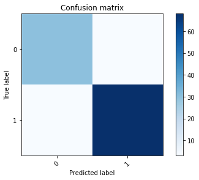

```python
print('Plotting confusion matrix')

outcome = encode_text_index(df, 'class')

plt.figure()
plot_confusion_matrix(cm_cnn, outcome)
plt.show()
```

```python
cnn_f1_4 = metrics.f1_score(cnn_y_true4, cnn_pred4, average='weighted')
print('\nAveraged F1: {}'.format(cnn_f1_4))


print(metrics.classification_report(cnn_y_true4, cnn_pred4))

cnn_score4 = metrics.accuracy_score(cnn_y_true4, cnn_pred4)
print('Accuracy: {}'.format(cnn_score4))
```

```
Averaged F1: 0.9423076923076923
              precision    recall  f1-score   support

           0       0.91      0.91      0.91        33
           1       0.96      0.96      0.96        71

    accuracy                           0.94       104
   macro avg       0.93      0.93      0.93       104
weighted avg       0.94      0.94      0.94       104

Accuracy: 0.9423076923076923
```

## Best Model Results for Fully Connected Neural Network Models (Model #2)

```python
cm_fcnn = metrics.confusion_matrix(y_true, pred2)
print("Confusion Matrix:\n")
print(cm_fcnn)
```

```
Confusion Matrix:

[[32  1]
 [ 1 70]]
```

```
Plotting confusion matrix
```

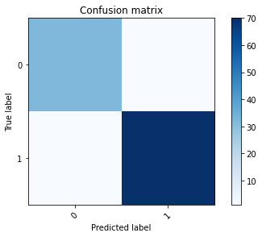

```python
print('Plotting confusion matrix')

outcome = encode_text_index(df, 'class')

plt.figure()
plot_confusion_matrix(cm_fcnn, outcome)
plt.show()
```

```python
score = metrics.accuracy_score(y_true, pred2)

print("Accuracy score: {}".format(score))
```

```
Accuracy score: 0.9807692307692307
```

```python
print(metrics.classification_report(y_true, pred2))
```

```
              precision    recall  f1-score   support

           0       0.97      0.97      0.97        33
           1       0.99      0.99      0.99        71

    accuracy                           0.98       104
   macro avg       0.98      0.98      0.98       104
weighted avg       0.98      0.98      0.98       104
```

## Results

Having played around with both neural network model types and models using Random Forest, KNN, and SVM algorithms, we were able to successfully use AI to predict diabetes risk among patients using the dataset provided by the UCI Repository. The model using Random Forest was able to perform with the highest accuracy score of 99%. For our best fully connected neural network model, its accuracy score was 98% and the CNN model had 94%. In our evaluation of the performance of CNN vs. fully connected neural network models, we have determined that CNN models are the better predictor for classification between the two neural network model types. This is due to the fact that the performance of the fully connected neural network models was very inconsistent. The accuracy scores range from low 30%'s to high 60%'s with very few instances going above the upper range. On the other hand, the CNN models would consistently perform with accuracy scores sitting above 80% on all trial runs. Therefore, we consider our best fully connected neural network model to be an outlier and our CNN model to be the best predictor of the two.